# Where did London outcodes outpace the rest of London?

Maps and spatial patterns of the all-outcode ranking (model: hm1.0)

Published

30 October 2026

# 1 Introduction

This report is a follow-up visualisation of report 05. Report 05 ranked every London outcode by how far its quality-adjusted house prices pulled ahead of, or fell behind, the rest of London between 2016 and 2025. Here we map that ranking and ask where the outcodes that outpaced or lagged the rest of London lie. The model, the joint test and the data are described in report 05 and are not repeated.

# 2 Mapping the outperforming outcodes

Figure 1 maps, for each outcode, the ratio of its price index to the rest of London’s in 2025, with both equal to 1 in 2016. A ratio of 1.10 means the outcode’s prices grew 10% more than the rest of London’s. The colours use a log scale, so that 0.8 and 1.25 are equally far from 1.

An outcode is coloured only if the joint test of report 05 rejects a common trend with the rest of London over its whole path since 2016, after adjusting for the 218 tests. The left panel uses Holm’s adjustment, which is strict: if no outcode truly differed, the chance of colouring even one would be at most 5%. The right panel uses the Benjamini-Hochberg (BH) adjustment, which is less strict: about 5% of the coloured outcodes are expected to be false calls. Outcodes not shown to differ are mid grey. Those that report 05 did not rank, with fewer than 30 sales in some year or fewer than 30 postcodes, are light grey. The outcode shapes are approximate (Appendix B).

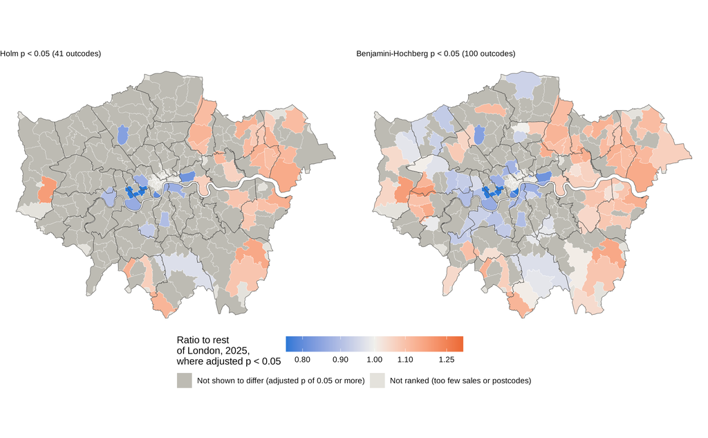

Figure 1: Ratio of each outcode’s price index to the rest of London’s in 2025 (2016 = 1). Coloured where the joint test rejects a common trend after adjusting for multiple testing: Holm (left) and Benjamini-Hochberg (right). Mid grey: tested, not rejected. Light grey: not ranked. Lines: borough boundaries. The colour scale runs from 0.76 to 1.31; the few outcodes beyond take the end colour.

Under Holm’s adjustment, 41 of the 218 ranked outcodes differ from the rest of London: 28 grew faster and 13 slower. Under BH, 100 do. The BH panel fills in more of the same picture rather than adding new areas.

The outperformers form a broad band across east and north-east London, from Walthamstow (E17) and Forest Gate (E7) out to Romford (RM) and Erith (DA8). Smaller groups lie in the south-east (Orpington, BR5 and BR6) and south (Sutton, SM3, and Coulsdon, CR5), and in the west around Hayes (UB3). The underperformers are almost all in central and west London: South Kensington (SW7), Earl’s Court (SW5), West Kensington (W14), Pimlico (SW1V), Fulham (SW6), Bayswater (W2), Southwark (SE1) and Whitechapel (E1).

Figure 2 shows the Holm panel as an interactive map. Hover over an outcode to see its rank, ratio and 95% interval, the unadjusted, Holm and BH p-values, and its numbers of sales and postcodes. The background map needs an internet connection; the outcodes and their results do not.

[interactive chart not shown]

Figure 2: Interactive map: ratio to the rest of London in 2025, coloured where Holm p < 0.05. Hover over an outcode for its results.

The ratios in Figure 1 are cumulative. Figure 3 shows how they built up year by year, for the same outcodes. The gaps opened gradually rather than in a single jump. Averaged over the Holm-rejected outcodes, the ratio of the outperformers rose from 1.02 in 2017 to 1.11 in 2025. That of the underperformers fell from 0.98 to 0.84.

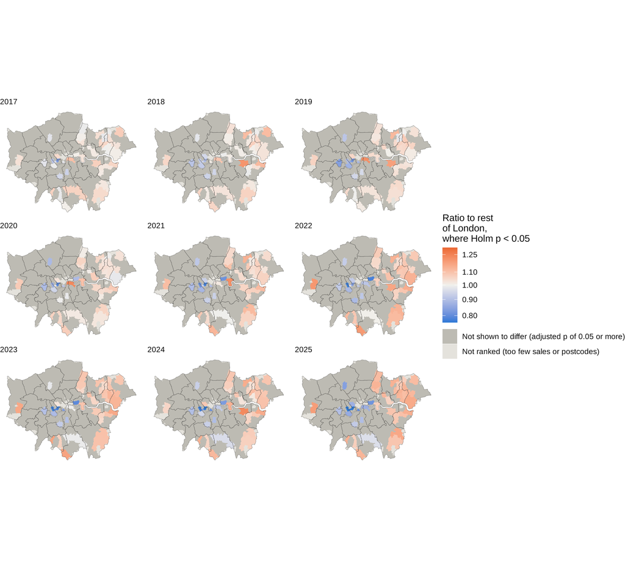

Figure 3: Ratio of each outcode’s price index to the rest of London’s in every year (2016 = 1), coloured where Holm p < 0.05 for the whole path. The same outcodes are coloured in every year, and the colour scale is the same in every panel.

# 3 What the outperformers have in common

The maps suggest that the outperformers lie further from the centre and more often in the east. Most were also relatively cheap in 2016, which points to prices converging across London over the period. This section looks more closely at how growth varies with distance to the centre and with the price level in 2016.

## 3.1 Distance to central London

The distance of an outcode to central London is the average straight-line distance from its sales’ postcodes to Charing Cross, the conventional centre of London. It therefore reflects where the homes are, not the outcode’s shape.

Figure 4 plots the ratio against this distance. The correlation between the log ratio and the distance to Charing Cross is 0.53 (95% CI 0.43 to 0.62). The relationship is steep within about 10 km of the centre and flat beyond 15 km. Table 1 puts numbers on it. Outcodes within 5 km grew on average 13% less than the rest of London. Those 20 km or more away grew 6% more. 11 of the 13 Holm-rejected underperformers lie within 10 km of the centre, and 21 of the 28 outperformers lie 15 km or more away.

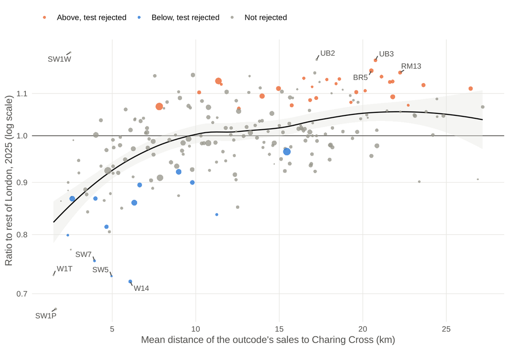

Figure 4: Ratio to the rest of London in 2025 against the outcode’s mean distance to Charing Cross, for the 218 ranked outcodes. Colour: Holm-adjusted joint test. Point size: number of sales. Line: loess smooth with 95% band. The five outcodes at each end of the ranking are labelled.

Table 1: Ranked outcodes by distance to Charing Cross: average ratio to the rest of London in 2025 (geometric mean) and the number of Holm-rejected outcodes above and below the rest of London

| Distance to Charing Cross | Outcodes | Average ratio | Above, Holm p < 0.05 | Below, Holm p < 0.05 |
| --- | --- | --- | --- | --- |
| Under 5 km | 28 | 0.87 | 0 | 6 |
| 5 to 10 km | 52 | 0.98 | 1 | 5 |
| 10 to 15 km | 51 | 1.01 | 6 | 1 |
| 15 to 20 km | 59 | 1.03 | 10 | 1 |
| 20 km or more | 28 | 1.06 | 11 | 0 |

## 3.2 Price level in 2016

An outcode’s price level in 2016 is its fixed effect in a hedonic regression of log price on property type, tenure and new-build status, fitted to the 2016 sales. It is expressed relative to the median outcode, so 2 means prices twice as high as in the median outcode for the same type of property.

Figure 5 asks whether cheaper outcodes caught up. The correlation between the log ratio and the log of the quality-adjusted 2016 price level is -0.73 (95% CI -0.78 to -0.66). The cheapest outcodes in 2016 grew most, and the most expensive grew least.

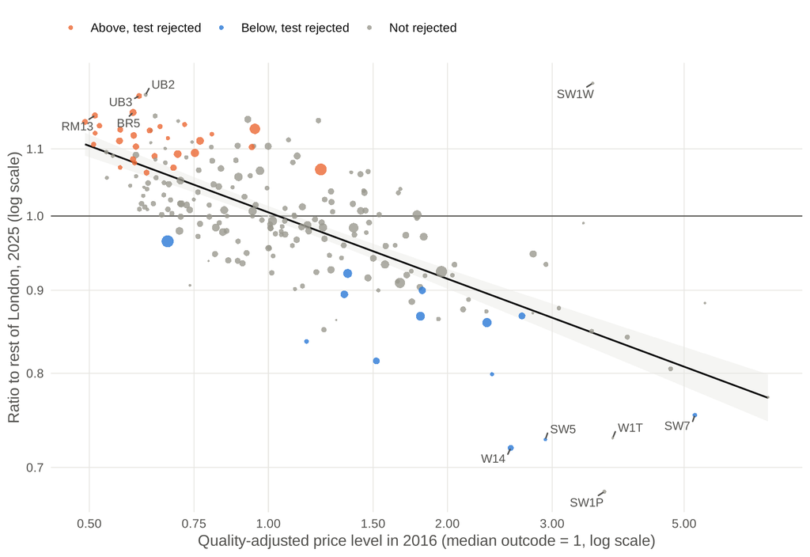

Figure 5: Ratio to the rest of London in 2025 against the outcode’s quality-adjusted price level in 2016 (median outcode = 1), for the 218 ranked outcodes. Both axes are on log scales. Colour: Holm-adjusted joint test. Point size: number of sales. Line: least squares fit with 95% band.

Two cautions apply. First, price level and distance are closely related: their correlation is -0.80, because central London is expensive. This figure and Figure 4 therefore largely describe the same pattern, and they cannot say whether it is location or price level that matters. Second, the 2016 level and the growth since 2016 are both estimated from the same 2016 sales, so chance error in those sales biases the figure towards a negative relationship. Measuring the starting price level with 2015 sales would remove this bias.

# 4 Spatial clustering

The maps show outperformers and underperformers in contiguous blocks. We test this with Moran’s I on the log ratio of the 218 ranked outcodes, which asks whether outcodes with similar ratios sit next to each other.

**Neighbours.** Two outcodes are neighbours if their boundaries touch, even at a single point. Each outcode’s neighbours get equal weights that sum to one, so the *neighbour average* of an outcode is the plain mean of its neighbours’ log ratios. One ranked outcode has no ranked neighbour and is left out.

**Global Moran’s I.** Let $z_i$ be outcode $i$’s log ratio minus the average log ratio of the $n$ outcodes, and $w_{ij}$ the weight of outcode $j$ in outcode $i$’s neighbour average (zero if $j$ is not a neighbour). The neighbour average of outcode $i$ is then $\sum_j w_{ij} z_j$, and

$$I = \frac{\sum_i z_i \sum_j w_{ij} z_j}{\sum_i z_i^2}.$$

With these weights, $I$ is the slope of a regression of each outcode’s neighbour average on its own $z_i$. It is close to zero (strictly $-1/(n-1)$) if the log ratios are placed at random across London. It is positive if outcodes with high ratios tend to have neighbours with high ratios, and those with low ratios neighbours with low ones. The p-value tests $I$ against random placement.

**Local Moran’s I.** The local statistic of outcode $i$ is

$$I_i = \frac{z_i \sum_j w_{ij} z_j}{m}, \qquad m = \frac{1}{n} \sum_k z_k^2.$$

It is the product of the outcode’s own $z_i$ and its neighbour average, divided by the variance $m$ of the log ratios. It is positive when both lie on the same side of the average, and negative when they lie on opposite sides. The global $I$ is the average of the $I_i$.

To judge whether an outcode resembles its neighbours more than chance would allow, we ask what $I_i$ would look like if its neighbours had been picked at random. We keep the outcode’s own $z_i$, give it the same number of neighbours drawn at random from the other outcodes, and compute $I_i$ again. Repeating this 999 times (with a fixed random seed) shows the range of $I_i$ that chance alone produces. The p-value measures how unusual the observed $I_i$ is within that range. A p-value below 0.05 means that the outcode and its actual neighbours are more alike, or more different, than random neighbours would be.

Each outcode with a p-value below 0.05 is then classified by two questions: did the outcode itself grow faster than the rest of London (ratio above 1), and did its neighbours on average? We compare with 1, the rest of London, rather than with the average outcode, so that “high” means growing faster than the rest of London. The answers give four classes:

|  | Neighbour average above 1 | Neighbour average below 1 |
| --- | --- | --- |
| **Outcode above 1** | *High among high*: part of a cluster of outperformers | *High among low*: an outperformer surrounded by slower areas |
| **Outcode below 1** | *Low among high*: an underperformer surrounded by faster areas | *Low among low*: part of a cluster of underperformers |

Outcodes with a p-value of 0.05 or more are shown as not significant.

The local tests are run once per outcode. Even with no clustering at all, about 11 of the 217 outcodes would have a p-value below 0.05 by chance, and these p-values are not adjusted for that. The cluster map is therefore a guide to where clusters lie, not proof that every outcode marked on it belongs to one. Whether clustering exists at all is answered by the single global test.

**Results.** Outcodes with similar ratios cluster strongly. Global Moran’s I is 0.53 (p <0.001), against about zero if the ratios were placed at random. Figure 6 shows where the clusters are. 28 outcodes form clusters of outperformers, mostly in a large block in east and south-east London and a smaller group around Hayes in the west (DA1, DA14, DA16, DA17, DA6, DA7, DA8, E10, E17, E6, E7, IG1, IG11, RM1, RM10, RM11, RM12, RM13, RM14, RM5, RM6, RM7, RM8, RM9, SE2, TW5, UB3 and UB4). 15 outcodes form a cluster of underperformers in inner west London (NW1, SW10, SW13, SW3, SW5, SW6, SW7, W11, W12, W14, W1H, W2, W4, W6 and W8). Only 2 outcodes are outliers from their neighbours (EC2Y and SW1W).

The clusters include 21 outcodes whose own test does not reject in Figure 1. Their ratios are modest on their own, but they sit among neighbours that move the same way. This strengthens the picture of broad regional trends rather than isolated local ones.

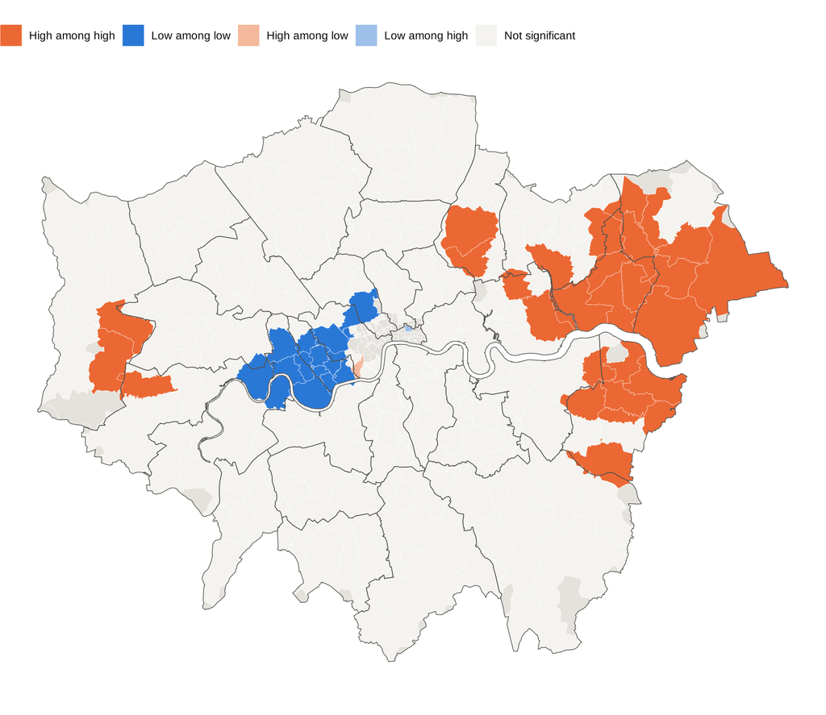

Figure 6: Local spatial clusters of the ratio to the rest of London (local Moran’s I, permutation p < 0.05, not adjusted for multiple testing). High or low: ratio above or below 1; among high or low: neighbour average above or below 1. Light grey: not ranked.

# 5 Conclusion

- **Where.** The outcodes that outpaced the rest of London since 2016 lie mostly in east and north-east London and on the outer edges of the south and west. Those that lagged are concentrated in central and west London.
- **Over time.** The gaps widened steadily over the period rather than appearing in one year.
- **A gradient from the centre.** Growth relative to the rest of London rises steeply with distance from the centre up to about 10 km, then levels off.
- **Cheaper areas caught up.** Outcodes that were cheaper in 2016 grew faster. This cannot be separated from distance to the centre, because prices in central London were also the highest in 2016.
- **Clusters, not scattered winners.** Outcodes with similar growth sit next to each other (Moran’s I 0.53), forming a large block of outperformers in the east and a block of underperformers in inner west London.
- **Reading.** The figures describe where prices grew faster or slower, not why. The strong spatial clustering also suggests shocks shared by neighbouring areas, which the postcode-clustered inference of report 05 does not cover (Appendix B).

# Appendix A: Precision of the ranking

Figure 7 plots each outcode’s ratio and 95% interval against its number of postcodes, which are the clusters behind its test. The intervals narrow as outcodes get larger. Several of the most extreme ratios belong to small outcodes with wide intervals, such as SW1W at the top of the ranking and SW1P and W1T at the bottom, and these are not rejected. A rank on its own is therefore weak evidence, as report 05 notes.

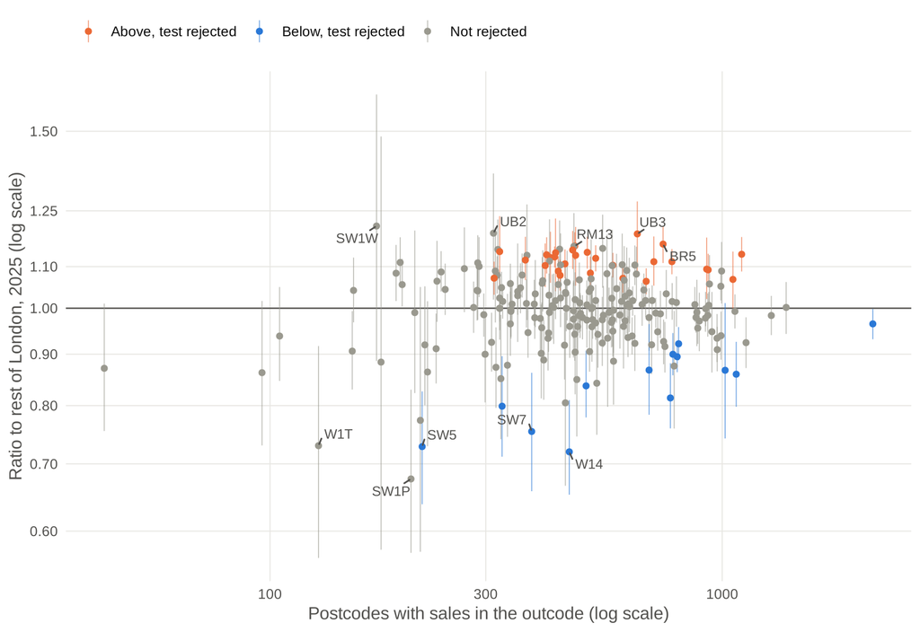

Figure 7: Ratio to the rest of London in 2025 with its 95% interval, against the number of postcodes with sales in the outcode, for the 218 ranked outcodes. Both axes are on log scales. Colour: Holm-adjusted joint test.

# Appendix B: Limitations

- **Boundaries.** There is no open official boundary file for outcodes, so the maps use approximate ones. Each postcode in the ONS Postcode Directory gets the area closer to it than to any other postcode (its Voronoi cell), and the cells are merged by outcode and clipped to the Greater London boundary. Only postcodes in use at some point since 2016, and only those of ordinary addresses, are kept; large-user postcodes would otherwise place non-geographic outcodes, such as CR9, inside others. The shapes are least accurate in sparsely built areas such as parks and the Green Belt. They affect the maps’ appearance, not the estimates, which come from the sales themselves.
- **Associations, not causes.** Distance and the 2016 price level describe where growth was faster. They do not explain it, and the two cannot be separated here.
- **Built-in correlation.** Chance error in the 2016 price level pushes measured growth since 2016 the opposite way, which biases Figure 5 towards a negative relationship. A starting level measured with 2015 sales would remove this bias.
- **Local clusters.** The local Moran’s I p-values are not adjusted for multiple testing, and the clusters depend on the definition of neighbours (shared borders). The global Moran’s I is the firmer result.
- **Shared local shocks.** The strong clustering means neighbouring outcodes move together. Report 05’s tests cluster errors by postcode, which does not cover shocks shared by a whole outcode or its neighbours. Its rejections may therefore be somewhat too confident (report 05, Appendices B and C).